# Topic Models Up & Down!

Theresa Gessler, Ece Kural, Gino Pauselli, Martin Riedl, Jiyoun Suk

3 August 2018

# The Problem

We often use topic models to get an overview of our corpus - but do topic models actually represent what humans think of as topics?

We use a generic corpus to assess this question.

## The Corpus

```r
news <- read_csv("C:/Users/theresa/Downloads/whatever.csv")
table(news$`_source.category`)
```

```
        _source.category           administration                      app
                      81                       78                       27
cheltenham-festival-2018           clarifications             competitions
                     449                       16                       79
             dear-deidre               dream-team                 fabulous
                    1129                      152                     8003
                  living                    money                   motors
                      15                     2669                     1000
                    news                opinion-2                  puzzles
                   22875                        1                        2
                   sport                     tech                   travel
                   20519                     1853                     1109
            tvandshowbiz            uncategorized                   videos
                   18932                      729                        2
          world-cup-2018
                    2214
```

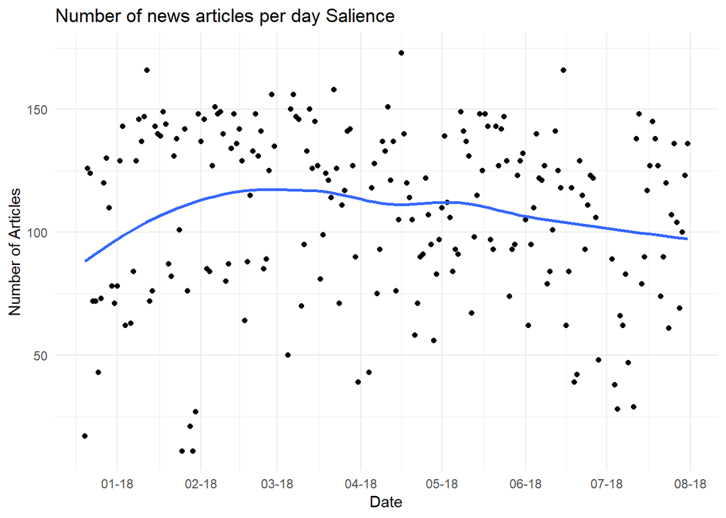

```r
news_only<-subset(news,news$`_source.category`=="news")
news_only <-subset(news_only,is.na(news_only$`_source.text`)==F)
news_only$text<-news_only$`_source.text`
news_only$date<-date(news_only$`_source.publication_date`)
news_only$count<-1
news_agg<-plyr::ddply(news_only,.(date),summarise,articles=sum(count))
ggplot(data=news_agg,mapping=aes(x=date,y=articles))+geom_point()+geom_smooth(se=F)+   scale_x_date(name="Date", date_breaks = "1 month", date_labels="%m-%y")+ggtitle("Number of news articles per day Salience")+    scale_y_continuous(name="Number of Articles") + theme_minimal()+guides(shape=F, alpha=F)
```

# Finding Topics bottom-up

Before running unsupervised methods to get an overview of our corpus, we wanted to get an overview ourselves. Similar to generating a manually annotated training sample, we annotated a randomly selected subset of documents. However, our selection we selected only 100 documents.

Below, we present our manual method of topic generation and its results. We call this **TJOPIC**: **T**opical **JO**urnalism **P**olitics **I**nternational Relations **C**lassification.

## Procedure

Each of us had the same task:

- read the first 20 documents, identify what you think of as a topic
- (as group) discuss if 15 may be an appropriate number
- read remaining 80 documents
- decide on topics
- attribute documents to topics
- determine 5 keywords per topic
  - this could be done in an automated word by checking for words that have high tf-idf scores in our documents
  - but in such a small sample, human choice seemed more effective
- (as group) discuss what we thought of as a topic
- (as group) decide on a common set of topics and keywords for further iterations
  - originally, we were planning to do our analysis for each teammember’s topic model - but we ran out of computing power for that

## Results

These are the topics each participant established:

```r
topics_across_people <- read_excel("C:/Users/theresa/Dropbox (Privat)/miniproject/topics_across_people.xlsx")
topics_across_people %>% kable(caption="Participant's Topics") %>%
  kable_styling() %>% row_spec(row = 0, bold=T)
```

Participant’s Topics

| ECE | GINO | JIYOUN | MARTIN | THERESA |
| --- | --- | --- | --- | --- |
| violence against women | Brexit | crime stories (serious - homicide, rape) | sex crime, rape, womankilling | murder |
| drug/gang/teenage violence | England | crime stories (light) | drugs, police, miscellaneous crime | crime (general) |
| health | health | daily lives (daily stories) | accidents | domestic Politics |
| royalty/gossip | international | (human accidents and) health/medication | health, disease, sickness | traffic |
| citizen news | lifestyle | political, international issue (non UK) | environment | digital / social media |
| environment | money | UK relations with Syria | human interest | Brexit |
| immigration | police | UK relations with EU | politics | human interest |
| child abuse | royalty | UK relations with other countries | russia | health |
| ME/war | science | domestic politics | war | sexual deviance |
| accident | sex | non-political international issue | internet | royals |
| political parties/politicians | Syria | UK Economy | economy | immigration |
| internet | technology | corporations | transportation | Syria |
| European relations | terrorism | entertainment (royal family, TV, celebrities) | immigration | war |
| business/finance/commercial | weird | environmental issue | sport | international politics |
| crime/murder | family | natural disaster (??) | entertainment | environment |

These are the specific topics and keywords that were the result of our joint discussion:

```r
topics<-c("Brexit", "England", "Health", "International", "Lifestyle", "Money", "Accident", "Royalty", "Science", "Sex", "Syria", "Technology", "Terrorism", "Family", "Crime")
keywords<-readtext("C:/Users/theresa/Desktop/miniproject/final_keywords.txt")
text = unlist(strsplit(keywords[1,2],"\n"))
N.query = length(text)
queries<-data.frame(text)
queries$name<-topics
queries %>% select("name","text") %>% kable(caption="Keywords per Topic") %>%
  kable_styling() %>% row_spec(row = 0, bold=T)
```

Keywords per Topic

| name | text |
| --- | --- |
| Brexit | Brexit Europe Brussels immigration sovereignty |
| England | Corbyn May Tories Labour UK |
| Health | health disease cure condition vaccine |
| International | international Trump Putin US Russia |
| Lifestyle | TV famous show star story |
| Money | money company finance commercial revenue |
| Accident | injure car death traffic accident |
| Royalty | royal Prince Queen Majesty Buckingham |
| Science | research findings artificial naturally environment |
| Sex | sex girl rape camera doll |
| Syria | Syria Assad Damascus regime chemical |
| Technology | Facebook Google information online video |
| Terrorism | terrorism Attack bomb ISIS threat |
| Family | father mum husband wife abuse |
| Crime | gang drug assault crime murder |

# Getting into information retrieval

## The Vector Space model

For this, we rely on the **vector space model** of text

Documents and queries are represented as vectors.

$d_j = ( w_{1,j} ,w_{2,j} , \dotsc ,w_{t,j} )$

$q = ( w_{1,q} ,w_{2,q} , \dotsc ,w_{n,q} )$

Each Dimension corresponds to a separate term. If a term occurs in the document, its value in the vector is non-zero. Several different ways of computing these values, also known as (term) weights, have been developed. We use tf-idf, that is term-frequency-inverse-document-frequency to weigh those words higher that are unique to specific documents.

### Advantages of vector space models

- simple model based on linear algebra
- continuous degree of similarity between queries & doucments - this allows a better comparison to LDA results
- allows ranking of documents according to relevance
- takes into account all our search terms (advantage over e.g. collocations or simple tf-idf)
- allows partial matching

### Limitations of vector space models

- long documents have smaller similarity values - but our documents are short
- semantic sensitivity: documents with similar context but different vocabulary won’t be associated
  - expansions with wordembeddings or synonyms from WordNet may overcome this
- weighting is intuitive but not mathematically derived
- assumption of word independence violated → maybe an overly simplified model of speech

## Writing our own Search Engine

Now, we create our search engine. We load our data - we will generate the dfm again from scratch. We do text preprocessing in quanteda, the actual search engine in tm so we convert our dfm into a document-term matrix

```r
load("C:/Users/theresa/Desktop/miniproject/news.RData")
news_only <-subset(news_only,is.na(news_only$`_source.text`)==F)
news_only$text<-news_only$`_source.text`
joined_df<-dplyr::bind_rows(news_only,queries)
full_corpus<-corpus(joined_df)
full_tokens<-tokens(full_corpus,remove_numbers=T,remove_punct=T)
full_dfm<-dfm(full_tokens,stem=T)
full_dfm<-dfm_remove(full_dfm,stopwords("en"))
full_dfm<-dfm_trim(full_dfm,min_docfreq = 228)

full_tm<-convert(full_dfm,"tm")
```

Now we transpose this into a Term-Document Matrix

```r
term.doc.matrix.stm<-as.TermDocumentMatrix(t(full_tm), weighting = weightTf)
```

First, we define some utility functions we will make use of:

- tf-idf weights from term frequency and document frequency
- getting weights per term from tf-idf weights
- store a variable with number of documents

```r
get.tf.idf.weights <- function(tf.vec, df) {
  weight = rep(0, length(tf.vec))
  weight[tf.vec > 0] = (1 + log2(tf.vec[tf.vec > 0])) * log2(N.docs/df)
  weight
}

get.weights.per.term.vec <- function(tfidf.row) {
  term.df <- sum(tfidf.row[1:N.docs] > 0)
  tf.idf.vec <- get.tf.idf.weights(tfidf.row, term.df)
  return(tf.idf.vec)
}
N.docs<-length(news_only$text)
N.queries<-length(topics)
```

Now we are all set to calculate the tfidf Matrix and get the most relevant documents for our set of keywords.

```r
tfidf.matrix <- t(apply(term.doc.matrix.stm, c(1), FUN = get.weights.per.term.vec))
tfidf.matrix <- scale(tfidf.matrix, center = FALSE, scale = sqrt(colSums(tfidf.matrix^2)))

doc.vector <- tfidf.matrix[, 1:N.docs]
doc.scores<-list(0)

for (i in 1:length(topics)) {
  query.vector <- tfidf.matrix[, (N.docs+i)]
  doc.scores[[i]] <- t(query.vector) %*% doc.vector
}
results_mat<-matrix(unlist(doc.scores),ncol=length(topics),dimnames=list(1:N.docs,topics))
results_mat<-cbind(results_mat,news_only$`_source.title`,news_only$`_source.text`)
save(results_mat,file="results.RData")
results_df <- data.frame(results_mat)
save(results_df,file="results_df.RData")
```

Let’s have a quick look at - the average relevance per topic - the titles of the most relevant texts for each topic

```r
results_df %>% select(-c(V16,V17)) %>% transmute_all(as.character) %>% transmute_all(as.numeric) %>% colMeans()
```

```
       Brexit       England        Health International     Lifestyle
  0.010110091   0.017695265   0.010435560   0.013166801   0.013162915
        Money      Accident       Royalty       Science           Sex
  0.007539139   0.012500448   0.011343859   0.009174101   0.013304028
        Syria    Technology     Terrorism        Family         Crime
  0.005230948   0.010641690   0.010108906   0.016148911   0.015130309
```

```r
vector<-sapply(results_df[1:length(topics)],which.max)
paste(topics,results_df$V16[vector])
```

```
 [1] "Brexit OPEN DOOR  Brexit migration row as PM suggests EU citizens could get more access to Britain even after we quit"
 [2] "England PMQS SCORE  Off came the Lenin cap and on went the gloves as Jeremy Corbyn tried to beat up Theresa May on council funding – but failed to land a blow"
 [3] "Health GAMER HEALTH FEARS  Video game addiction set to be classified as a mental health condition by the World Health Organisation"
 [4] "International 'POWERFUL FORCES ARE AT WORK'  Vladimir Putin claims there’s a secret conspiracy to destroy relations between Russia and the US"
 [5] "Lifestyle DAY AT THE RACES  Party spirit at Epsom Derby 2018 as celebs and thousands of racegoers glam up for the big day"
 [6] "Money KIM JONG JEZ  Jeremy Corbyn ‘wants to turn London into a Communist city like Pyongyang’ by shrinking the finance sector"
 [7] "Accident NEVER DO MAKE UP IN THE CAR  Taxi passenger ends up with eyeliner pencil stuck in her EYE after car crashes while she was doing her make-up"
 [8] "Royalty ROYAL TALL ORDER  The 5ft 3in Queen appoints a 7ft 2in giant to be one of her key aides"
 [9] "Science BATTY FOR CHANGE  Theresa May reveals she has put boxes for birds, owls and bats in her garden to do her bit as she reveals radical Government plan for the environment"
[10] "Sex ASYLUM RAPIST CAGED  British Army interpreter jailed for drugging and raping a girl of 14"
[11] "Syria THERESA MAY  Syrian children are gasping for life as Assad’s gas chokes them — it must stop now"
[12] "Technology 'BEYOND SHOCKING'  Rape victims identified by Google as searches for attackers reveal victims too"
[13] "Terrorism FRESH TERROR  New terror cult called ‘the youth’ could replace ISIS in 2018"
[14] "Family SELF-DOUBT  What is gaslighting, where does the term come from and is it a form of abuse within relationships?"
[15] "Crime PRISON CRACKDOWN  Kingpins running drugs gangs from their cell will be moved to top security jails alongside terrorists and murderers under new Government crackdown"
```

For those of you who want more detail, we offer a selection of some curious **traffic news** from the UK, selected by our very own search engine / topic model!

```r
sorted_results <- results_df[order(results_df$Accident, decreasing = TRUE), ]
head(sorted_results$V17)
```

```
                                                                                                                                                                                                                                                                                                            …
HORRIFYING pictures shows a woman with a make-up pencil stuck in her eye socket – after a "minor" traffic bump yesterday in Bangkok. The unnamed victim, aged in her 20s, was using the eye liner pen while sitting in a cab during slow-moving traffic in the Thai capital at 5pm local time on Tuesday. Bu…
                                                                                                                                                                                                                                                                                                            …
                                                                                                                                                                                                                                                                                                            …
                                                                                                                                                                                                                                                                                                            …
                                                                                                                                                                                                                                                                                                            …
                                                                                                                                                                                                                                                                                                            …
                                                                                                                                                                                                                                                                                                            …
                                                                                                                                                                                                                                                                                                            …
                                                                                                                                                                                                                                                                                                            …
                                                                                                                                                                                                                                                                                                            …
                                                                                                                                                                                                                                                                                                            …
22804 Levels: 'BLEEDING Eye Fever' that’s deadlier than the plague has killed four and infected dozens in East Africa, as health chiefs warn the spread could be “catastrophic”. The horrific new disease could be about to bring fresh misery to the continent – so soon after the deadly Ebola outbreak of…
```

Finally, let’s see how many articles are completely outside our keywords

```r
results_df<-results_df %>% transmute_all(as.character) %>% transmute_all(as.numeric) %>% transmute(Summe=Brexit+England+Health+International+Lifestyle+Money+Accident+Royalty+Science+Sex+Syria+Technology+Terrorism+Family+Crime)
table(results_df$Summe==0)
```

```
FALSE  TRUE
22514   292
```

# Comparison with LDA

How do our results compare to LDA?

We calculate an LDA topic model as implemented in the *topicmodel* package.

[figure not shown]

```
# A tibble: 50 x 16
      X1 `Topic 1` `Topic 2` `Topic 3` `Topic 4` `Topic 5` `Topic 6`
   <int> <chr>     <chr>     <chr>     <chr>     <chr>     <chr>
 1     1 trump     stori     year      can       royal     like
 2     2 us        pay       world     hospit    harri     get
 3     3 presid    us        one       health    meghan    just
 4     4 russia    video     first     doctor    princ     go
 5     5 russian   onlin     nation    medic     wed       one
 6     6 attack    call      day       caus      day       say
 7     7 state     sun       also      use       queen     peopl
 8     8 countri   email     time      patient   also      think
 9     9 north     team      number    found     famili    look
10    10 war       news      can       cancer    william   becaus
# ... with 40 more rows, and 9 more variables: `Topic 7` <chr>, `Topic
#   8` <chr>, `Topic 9` <chr>, `Topic 10` <chr>, `Topic 11` <chr>, `Topic
#   12` <chr>, `Topic 13` <chr>, `Topic 14` <chr>, `Topic 15` <chr>
```

```r
library(data.table)
library(tm)
library(topicmodels)
library(tidytext)
library(dplyr)
library(tidyr)
library(ggplot2)
library(readr)
library(quanteda)
library(lubridate)
data <- fread("whatever.csv")

news <- subset(data, data$'_source.category'=="news") #subsetting the news category

#creating dtm using tm
text_corpus<- Corpus(VectorSource(as.vector(news$`_source.text`)))
text_corpus
text_corpus <- tm_map(text_corpus, content_transformer(removePunctuation)) %>%
        tm_map(content_transformer(tolower)) %>% # whether lower the text or not
        tm_map(content_transformer(stripWhitespace))
data(stop_words)
stoplist <-unlist(stop_words[,1])
text_corpus <- tm_map(text_corpus, content_transformer(removeWords), stoplist)
text_corpus  <- tm_map(text_corpus, content_transformer(stemDocument), language = "english")


text_dtm <- DocumentTermMatrix(text_corpus)
text_dtm_sparse <- removeSparseTerms(text_dtm, 0.990)

#creating dtm using quanteda
news_only<-subset(data,data$`_source.category`=="news")

news_only$year<-year(news_only$`_source.publication_date`)

news_only$nchar<-nchar(news_only$`_source.text`)

news_only %>%subset(is.na(news_only$nchar)==F) %>% summarise(overall=sum(nchar))

news_only <-subset(news_only,is.na(news_only$`_source.text`)==F)

news_only2 <- subset(news_only, !nchar==0) #remove nchar=0

news_only2$text<-news_only2$`_source.text`
full_corpus<-corpus(news_only2)
full_tokens<-tokens(full_corpus,remove_numbers=T,remove_punct=T)
full_dfm<-dfm(full_tokens,stem=T)
full_dfm<-dfm_remove(full_dfm,stopwords("en"))
full_dfm<-dfm_select(full_dfm, c("[-A-Za-z0-9_.%]+@[-A-Za-z0-9_.%]+\\.[A-Za-z]+"), selection="remove", valuetype = "regex")
full_dfm<-dfm_select(full_dfm, c("@the-sun.co.uk", "www.facebook.com", "thesun.co.uk"), selection="remove", valuetype = "fixed")
full_dfm<-dfm_select(full_dfm, c("said", "will"), selection="remove", valuetype = "fixed")
full_dfm<-dfm_trim(full_dfm,min_docfreq = 228)

full_tm<-convert(full_dfm,"tm") #convert to tm

#full_tm <- convert(full_dfm, to = "tm") %>% weightTfIdf() #doesn't work with LDA

#remove empty cells in dtm
rowSum <- apply(full_tm , 1, sum)
documents <- full_tm[rowSum> 0, ]

#LDA
k <- 15
control_LDA_Gibbs <- list(alpha = 12/k, estimate.beta = T,
                          verbose = 0, prefix = tempfile(),
                          save = 0, keep = 50,
                          seed = 980,
                          nstart = 1, best = T,
                          delta = 0.1,
                          iter = 100,
                          burnin = 10)


set.seed(123)
text_lda_15 <- LDA(documents, k, method = "Gibbs", control = control_LDA_Gibbs) #this is the one

terms(text_lda_15, 10)
terms <- as.data.frame(terms(text_lda_15,50))
write.csv(terms, "ldaout.terms.csv")
text_lda_topics <- topics(text_lda_15)
lda.topics <- as.data.frame(text_lda_topics)
write.csv(lda.topics, "ldaout.topics.csv")
```

## Comparison of TJOPIC_x and LDA

Based on our entire document set, we calculate correlations between our human coded topics and the topics found by LDA. Unfortunately, LDA found a number of very mixed topics that do not make sense by themselves. We assess the correlation of those topic shares in LDA

```r
load("text_lda_gamma.RData")
lda_international<-text_lda_gamma %>% dplyr::filter(topic==1)
lda_Royalty<-text_lda_gamma %>% dplyr::filter(topic==5)
lda_crime<-text_lda_gamma %>% dplyr::filter(topic==14)
lda_Economy<-text_lda_gamma %>% dplyr::filter(topic==13)
lda_Brexit<-text_lda_gamma %>% dplyr::filter(topic==10)
lda_Family<-text_lda_gamma %>% dplyr::filter(topic==8)
lda_Health<-text_lda_gamma %>% dplyr::filter(topic==4)
lda_Sex<-text_lda_gamma %>% dplyr::filter(topic==15)
lda_Royalty<-text_lda_gamma %>% dplyr::filter(topic==5)

load("C:/Users/theresa/Dropbox (Privat)/miniproject/results_df.RData")
results_df <- results_df %>% dplyr::select(-c(V16,V17))%>% mutate_all(as.character) %>% mutate_all(as.numeric)
cor_international<-cor(x=results_df$International,y=lda_international$gamma, method = "pearson")
cor_Family<-cor(x=results_df$Family,y=lda_Family$gamma, method = "pearson")
cor_Crime<-cor(x=results_df$Crime,y=lda_crime$gamma, method = "pearson")
cor_International<-cor(x=results_df$International,y=lda_international$gamma, method = "pearson")
cor_Sex<-cor(x=results_df$Sex,y=lda_Sex$gamma, method = "pearson")
cor_Royalty<-cor(x=results_df$Royalty,y=lda_Royalty$gamma, method = "pearson")
cor_Health<-cor(x=results_df$Health,y=lda_Health$gamma, method = "pearson")
cor_Brexit<-cor(x=results_df$Brexit,y=lda_Brexit$gamma, method = "pearson")
cor_Money<-cor(x=results_df$Money,y=lda_Economy$gamma, method = "pearson")
#cor_<-cor(x=results_df$,y=lda_$gamma, method = "pearson")

cat("Correlation for Royal Topic ",cor_Royalty,"\n")
cat("Correlation for Brexit Topic ",cor_Brexit,"\n")
cat("Correlation for Health Topic ",cor_Health,"\n")
cat("Correlation for Crime Topic ",cor_Crime,"\n")
cat("Correlation for Economy / Money Topic ",cor_Money,"\n")
cat("Correlation for Sex (Crime) Topic ",cor_Sex,"\n")
cat("Correlation for Family Topic ",cor_Family,"\n")
cat("Correlation for International Topic ",cor_International,"\n")
```

```
Correlation for Royal Topic  0.8189142
```

```
Correlation for Brexit Topic  0.7295401
```

```
Correlation for Health Topic  0.5441164
```

```
Correlation for Crime Topic  0.3476766
```

```
Correlation for Economy / Money Topic  0.3348176
```

```
Correlation for Sex (Crime) Topic  0.404992
```

```
Correlation for Family Topic  0.3751583
```

```
Correlation for International Topic  0.6831407
```

We present scatter plots of the least and most correlated examples, namely Economy / Money and Royalty

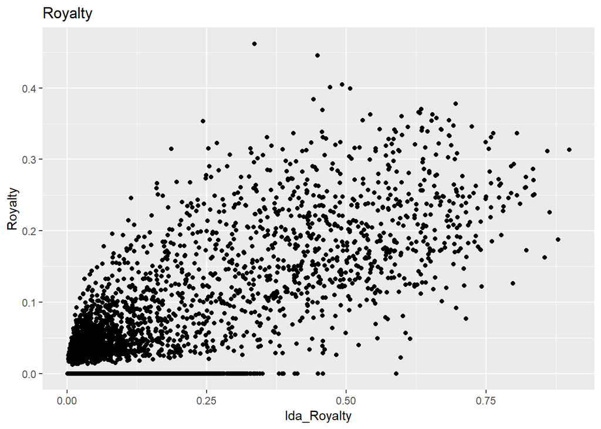

```r
ggplot(data=results_df, aes(x=lda_Royalty,y=Royalty))+geom_point()+ggtitle("Royalty")
```

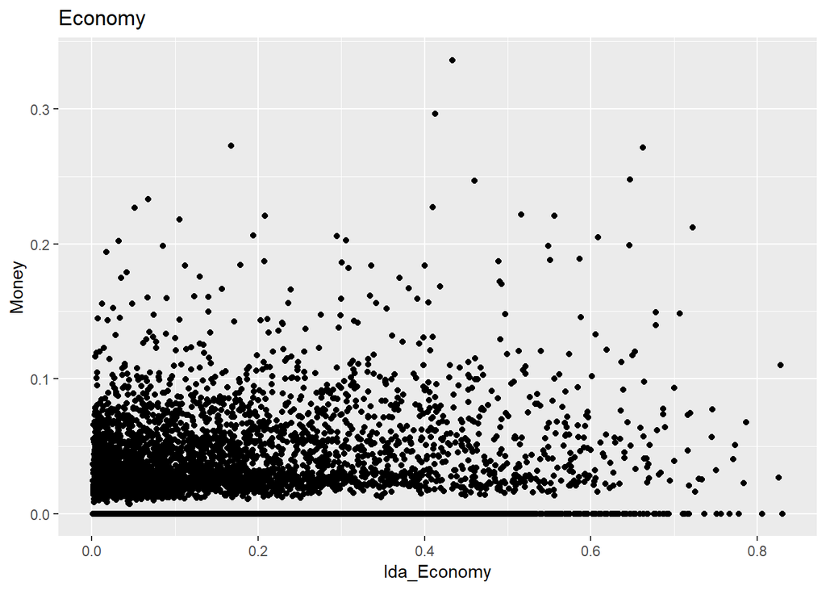

```r
ggplot(data=results_df, aes(x=lda_Economy,y=Money))+geom_point()+ggtitle("Economy")
```

# Replication with additional keywords

For comparison purposes, we replicate our analysis with a higher number of keywords. Unfortunately, we do not extract them recursively from our highest likelihood documents but based on keyness statistics for each individual word - we needed to compute in parallel to finish…

```r
topics<-c("Brexit", "England", "Health", "International", "Lifestyle", "Money", "Accident", "Royalty", "Science", "Sex", "Syria", "Technology", "Terrorism", "Family", "Crime")
topics_matrix <- read_csv("C:/Users/theresa/Downloads/topics_matrix2.csv") %>% select(-"1")
text = data.frame(t(topics_matrix), stringsAsFactors = F)
queries<-text %>% mutate(text=paste(X1,X2,X3,X4,X5,X6,X7,X8,X9,X10,X11,X12,X13,X14,X15,X16,X17,X18,X19,X20,X21,X22,X23,X24,X25,X26,X27,X28,X29,X30,X31,X32,X33,X34,X35,X36,X37,X38,X39,X40,X41,X42,X43,X44,X45,X46,X47,X48,X49,X50,X51,X52,X53,X54,X55,X56,X57,X58,X59,X60,X61,X62,X63,X64,X65,X66,X67,X68,X69,X70,X71,X72,X73,X74,X75,X76,X77,X78,X79,X80,X81,X82,X83,X84,X85,X86,X87,X88,X89,X90,X91,X92,X93,X94,X95,X96,X97,X98,X99))
#queries<-tidyr::unite(text, text, sep = " ", remove = TRUE)
queries$name<-topics
#queries$text<-iconv(queries$text,"UTF-8")
queries %>% dplyr::select("name","text") %>% kable(caption="Keywords per Topic") %>%
  kable_styling() %>% row_spec(row = 0, bold=T)
```

Keywords per Topic

| name | text |
| --- | --- |
| Brexit | eu theresa deal davis vote referendum britain brussels cabinet customs secretary negotiations pm mayâ tory remainers mrs trade may europe eastern across britain continental mainland measles countries … |
| England | jeremy labour mr anti-semitism leader jewish party dymic anti-semitic czech mcdonnell hard-left mps shadow hodge sarkocy mural labourâ anti-semite may theresa mrs brexit prime pm cabinet eu minister 1… |
| Health | mental nhs problems public england hunt care issues safety service secretary obesity phe department flu organisation risk jeremy patients disease diagnosed cancer diabetes neurone heart lyme infected … |
| International | development airport amnesty trade definition mordaunt secretary remembrance oxfam liam fox holocaust sanctions aid penny law department committee relations trump donald president kim melania summit da… |
| Lifestyle | presenter reality show star watching host interview watch movies channel series shows viewers watched mcpartlin screens broadcast programmes drama famous rich faces world iconic louis became include d… |
| Money | handing jackpot laundering amount life-changing sipping tonight’s jetting hush notice raise lottery champagne results taxpayersâ spent won euromillions super pound multi-million every per since britai… |
| Accident | and and and and and and and and and and and and and and and and and and and car park crash driver parked driving road vehicle parking drove smashed boot seat drive police bonnet windscreen bmw toyota … |
| Royalty | wedding meghan prince harry markle windsor queen duchess highness navy family infirmary palace duke ascot princess marines chapel college prince harry meghan charles markle william wedding royal harry… |
| Science | cancer commissioned suggests institute study found alzheimerâ shows porton prostate scientific scientists university studies professor dr centre according facility findings journal published presented… |
| Sex | offenders oral offender consensual dolls doll register abuse raniere sexual scandal perform act slave trafficking non-consensual oxfam rape weinstein girl little teenage 14-year-old 15-year-old baby e… |
| Syria | iraq chemical isis strikes assad airstrikes military lebanon missiles bashar russia kurdish weapons fighters kotey caliphate jihadi attack retaliation assad chemical regime bashar syrian syria weapons… |
| Technology | @thesun www.facebook.com thesun android iphone account main follow twitter experience page updates bring click posted ever us post like google doodle pumpkins homepage o’s doodles decorate founders th… |
| Terrorism | counter acts preparation threat policing command terrorist islamist act terror islamic focus preparing encouraging section threats commissioner attacks counts attack chemical terror salisbury nerve he… |
| Family | mother thomas son daughter markle cared dad aisle meghan family brother meghan’s samantha reclusive grandfather sr attending ragland wedding mum doria dad daughter son baby ragland roberta sister hear… |
| Crime | members mercer grullon croxteth rival moped violence rivals thugs mariam machete member beheading turf drill strand yates rhys violent drug dealers dealer addict cannabis addiction overdose prescripti… |

Now, we create our search engine. We load our data - we will generate the dfm again from scratch. We do text preprocessing in quanteda, the actual search engine in tm so we convert our dfm into a document-term matrix

```r
load("C:/Users/theresa/Desktop/miniproject/news.RData")
news_only <-subset(news_only,is.na(news_only$`_source.text`)==F)
news_only$text<-news_only$`_source.text`
joined_df<-dplyr::bind_rows(news_only,queries)
full_corpus<-corpus(joined_df)
full_tokens<-tokens(full_corpus,remove_numbers=T,remove_punct=T)
full_dfm<-dfm(full_tokens,stem=T)
full_dfm<-dfm_remove(full_dfm,stopwords("en"))
full_dfm<-dfm_trim(full_dfm,min_docfreq = 228)

full_tm<-convert(full_dfm,"tm")
```

Now we transpose this into a Term-Document Matrix

```r
term.doc.matrix.stm<-as.TermDocumentMatrix(t(full_tm), weighting = weightTf)
```

First, we define some utility functions we will make use of:

- tf-idf weights from term frequency and document frequency
- getting weights per term from tf-idf weights
- store a variable with number of documents

```r
get.tf.idf.weights <- function(tf.vec, df) {
  weight = rep(0, length(tf.vec))
  weight[tf.vec > 0] = (1 + log2(tf.vec[tf.vec > 0])) * log2(N.docs/df)
  weight
}

get.weights.per.term.vec <- function(tfidf.row) {
  term.df <- sum(tfidf.row[1:N.docs] > 0)
  tf.idf.vec <- get.tf.idf.weights(tfidf.row, term.df)
  return(tf.idf.vec)
}
N.docs<-length(news_only$text)
N.queries<-length(topics)
```

Now we are all set to calculate the tfidf Matrix and get the most relevant documents for our set of keywords.

```r
tfidf.matrix <- t(apply(term.doc.matrix.stm, c(1), FUN = get.weights.per.term.vec))
tfidf.matrix <- scale(tfidf.matrix, center = FALSE, scale = sqrt(colSums(tfidf.matrix^2)))

doc.vector <- tfidf.matrix[, 1:N.docs]
doc.scores<-list(0)

for (i in 1:length(topics)) {
  query.vector <- tfidf.matrix[, (N.docs+i)]
  doc.scores[[i]] <- t(query.vector) %*% doc.vector
}
results_mat<-matrix(unlist(doc.scores),ncol=length(topics),dimnames=list(1:N.docs,topics))
results_mat<-cbind(results_mat,news_only$`_source.title`,news_only$`_source.text`)
save(results_mat,file="results_100.RData")
results_df <- data.frame(results_mat)
save(results_df,file="results_df_100.RData")
```

Let’s have a quick look at - the average relevance per topic - the titles of the most relevant texts for each topic

```r
results_df %>% select(-c(V16,V17)) %>% transmute_all(as.character) %>% transmute_all(as.numeric) %>% colMeans()
```

```
       Brexit       England        Health International     Lifestyle
   0.03040046    0.03402748    0.03832330    0.02846502    0.03313198
        Money      Accident       Royalty       Science           Sex
   0.04022768    0.03050311    0.02187939    0.03101304    0.04057663
        Syria    Technology     Terrorism        Family         Crime
   0.01602267    0.03541884    0.02169309    0.03218342    0.02997225
```

```r
vector<-sapply(results_df[1:length(topics)],which.max)
paste(topics,results_df$V16[vector])
```

```
 [1] "Brexit STINGING PAIN  Toddler, three, raced to A&E after being stung 18 times by colony of angry bees"
 [2] "England Call May Bluff  Theresa May plans to issue back-me-or-sack-me challenge to Brexit rebels"
 [3] "Health SPICE IT UP  Cancer patient, 67, ‘beats the disease with the help of TURMERIC’ after five years of chemo failed"
 [4] "International ‘HARMFUL FOR EVERYONE’  Vladimir Putin claims Western sanctions HAVEN’T worked because they’ve hit the EU just as hard"
 [5] "Lifestyle STORM’S A-BREWIN!  Donald Trump’s alleged porn star lover Stormy Daniels ‘offered £750k to go on Celebrity Big Brother’"
 [6] "Money WITCH'S SPAT  Furious couple armed with umbrella and carving knife attack neighbour over noisy full-moon ritual"
 [7] "Accident BUS CRASH  Germany bus crash leaves 9 British schoolchildren hurt in head-on collision in Voehrenbach"
 [8] "Royalty NOT SO SHARP  Veteran sues hospital after SCALPEL was left in his abdomen for FOUR YEARS after prostate surgery"
 [9] "Science COULD IT BE YOU?  Lucky Brit winner scoops the entire £120million EuroMillions jackpot and becomes Britain’s third biggest winner"
[10] "Sex CHILD RAPIST  Boy, 15, admits four rapes on kids as young as FIVE and string of sex assaults"
[11] "Syria LITTER OF THE LAW  Cops blasted for picking up litter from streets instead of tackling crime"
[12] "Technology GUNNED DOWN  Boy, 17, dies after being shot in South London street in broad daylight"
[13] "Terrorism 'EVEN THE ROYALS WON'T BE LEFT ALONE'  ISIS terror suspect ‘posted chilling photo of Prince George outside his school next to Jihadi fighter’"
[14] "Family ROLE MODELS?  Who are Meghan Markle’s parents, are her mum and dad still together, will they attend the wedding and who are their children?"
[15] "Crime IN THE MONEY  Shameless Albanian gangsters from notorious Hellbanianz cartel brag on Instagram of their London cocaine dealing cash"
```

For those of you who want more detail, we offer a selection of some curious traffic news from the UK, selected by our very own search engine / topic model!

```r
sorted_results <- results_df[order(results_df$Accident, decreasing = TRUE), ]
head(sorted_results$V17)
```

```
                                                                                                                                                                                                                                                                                                            …
                                                                                                       NINE British teenagers have been injured in a bus crash in Germany. The accident happened when a 90-year-old man lost control of his car and crashed head-first into the double-decker vehicle in the…
                                                                                                                                                                                                                                                                                                            …
                                                                                                                                                                                                                                                                                                            …
                                                                                                                                                                                                                                                                                                            …
                                                                                                                                                                                                                                                                                                            …
                                                                                                                                                                                                                                                                                                            …
                                                                                                                                                                                                                                TWO teenagers found dead in a crashed car may have lay undiscovered in the w…
                                                                                                                                                                                                                                                                                                            …
                                                                                                                                                                                                                                                                                                            …
                                                                                                                                                                                                                                                                                                            …
THIS is the horrifying moment a driver pulled out in front of an HGV as it was travelling along the A55 towards Chester. The crash occurred last November near Llanddulas in Wales when the female driver of the silver car pulled out from a lay-by. The dashcam footage shows the lorry slowing down as th…
22804 Levels: 'BLEEDING Eye Fever' that’s deadlier than the plague has killed four and infected dozens in East Africa, as health chiefs warn the spread could be “catastrophic”. The horrific new disease could be about to bring fresh misery to the continent – so soon after the deadly Ebola outbreak of…
```

Finally, let’s see how many articles are completely outside our keywords

```r
results_df<-results_df %>% transmute_all(as.character) %>% transmute_all(as.numeric) %>% transmute(Summe=Brexit+England+Health+International+Lifestyle+Money+Accident+Royalty+Science+Sex+Syria+Technology+Terrorism+Family+Crime)
table(results_df$Summe==0)
```

```
FALSE  TRUE
22805     1
```

```r
head(results_df$V17[results_df$Summe==0])
```

[output not shown]

## Comparison of TJOPIC_x100 and LDA

Based on our entire document set, we calculate correlations between our human coded topics and the topics found by LDA. Unfortunately, LDA found a number of very mixed topics that do not make sense by themselves. We assess the correlation of those topic shares in LDA

```r
load("text_lda_gamma.RData")
results_df <- results_df %>% dplyr::select(-c(V16,V17))%>% mutate_all(as.character) %>% mutate_all(as.numeric)
cor_international<-cor(x=results_df$International,y=lda_international$gamma, method = "pearson")
cor_Family<-cor(x=results_df$Family,y=lda_Family$gamma, method = "pearson")
cor_Crime<-cor(x=results_df$Crime,y=lda_crime$gamma, method = "pearson")
cor_International<-cor(x=results_df$International,y=lda_international$gamma, method = "pearson")
cor_Sex<-cor(x=results_df$Sex,y=lda_Sex$gamma, method = "pearson")
cor_Royalty<-cor(x=results_df$Royalty,y=lda_Royalty$gamma, method = "pearson")
cor_Health<-cor(x=results_df$Health,y=lda_Health$gamma, method = "pearson")
cor_Brexit<-cor(x=results_df$Brexit,y=lda_Brexit$gamma, method = "pearson")
cor_Money<-cor(x=results_df$Money,y=lda_Economy$gamma, method = "pearson")
#cor_<-cor(x=results_df$,y=lda_$gamma, method = "pearson")

cat("Correlation for Royal Topic ",cor_Royalty,"\n")
cat("Correlation for Brexit Topic ",cor_Brexit,"\n")
cat("Correlation for Health Topic ",cor_Health,"\n")
cat("Correlation for Crime Topic ",cor_Crime,"\n")
cat("Correlation for Economy / Money Topic ",cor_Money,"\n")
cat("Correlation for Sex (Crime) Topic ",cor_Sex,"\n")
cat("Correlation for Family Topic ",cor_Family,"\n")
cat("Correlation for International Topic ",cor_International,"\n")
```

[output not shown]

```r
ggplot(data=results_df, aes(x=lda_Royalty,y=Royalty))+geom_point()+ggtitle("Royalty")
ggplot(data=results_df, aes(x=lda_Economy,y=Money))+geom_point()+ggtitle("Economy")
```

[output not shown]